# Project 2 Phase 2 - Clustering

Ashmitha,Keerthana

# Data Loading And Cleaning

```r
library(reshape2)
library(dplyr)
library(ggplot2)
library(gridExtra)
library(grid)
library(ggplot2)
library(lattice)
library(corrplot)
library("cluster")
library("factoextra")
library("magrittr")
obser<-read.csv("/Users/Ashmitha/Downloads/Subs/R/dane_obserwacyjne_v2.csv", header=TRUE, encoding="UTF-8")
```

In cleansing step we will prepare the data set to start analysis phase, we see that time in seconds columns, parent’s mood and tiredness columns has NULL so we will replace that by 0.

```r
sub.num <- obser %>% select(which(sapply(obser, is.numeric)))
obser$time_s[is.na(obser$time_s)] <- 0
obser$R_zmeczenie[is.na(obser$R_zmeczenie)] <- 0
obser$D_zm.U.0119.czenie[is.na(obser$D_zm.U.0119.czenie)] <- 0
```

# Prepare The Final DataSet

In this step we will fetch all needed data for analysis and visualization, and the most important for us are: ID, time_s(Consumed Time in seconds)

```r
sum_time_spent = obser %>%
 group_by(ID) %>%
 summarise(sum_time = sum(time_s))
head(sum_time_spent)
```

```
## # A tibble: 6 x 2
##      ID sum_time
##   <int>    <dbl>
## 1     1     5805
## 2     2     2750
## 3     3     6802
## 4     4     7178
## 5     5     7175
## 6     6     5338
```

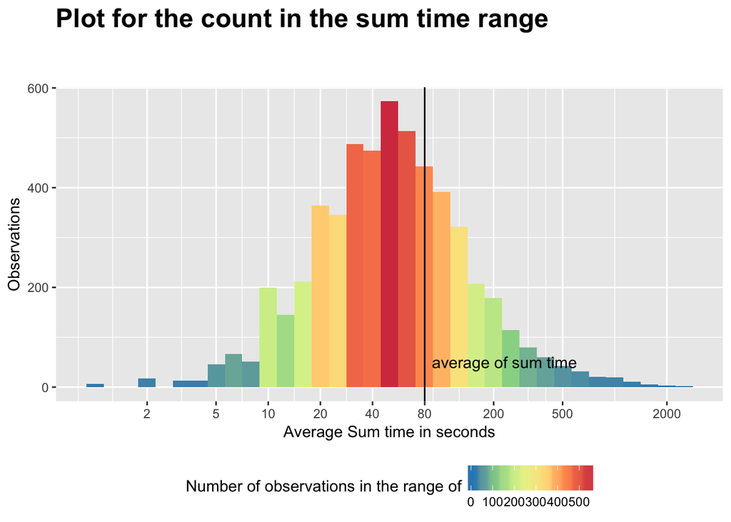

```r
av1 = as.integer(mean(obser$time_s))

Avg_Sum_time_plot = ggplot(data=obser, aes(time_s, fill = ..count..)) +
 geom_histogram(binwidth = 0.1) +
 scale_x_log10(breaks = c(2,5,10,20,40,200,500,2000,av1)) +
 scale_fill_distiller(palette = "Spectral")+
 geom_vline(aes(xintercept=av1)) + ylab("Observations") + xlab("Average Sum time in seconds") +
 ggtitle(expression(atop(bold("Plot for the count in the sum time range")))) +
 theme(plot.title = element_text(size = 18, face = "bold")) +
 theme(legend.position="bottom") + labs(fill="Number of observations in the range of") +
 annotate("text", x = av1, y = 50, label = "average of sum time", hjust = -0.05)

Avg_Sum_time_plot
```

For our data

```
-it is seen that the category of the exhibit is 2 or 3 whenever the parent's mood is other than 1(bad mood)
-Only the exhibit category 1 has to be considered !!!
-Most visited categories are counted
-Total time spent by each pair in each exhibit is calculated
```

The classification of objects, into clusters, requires some methods for measuring the distance or the (dis)similarity between the objects.

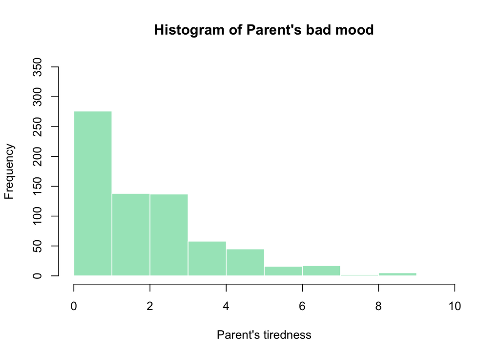

```r
obs_ex_times = obser %>% group_by_(.dots=names(.)[c(3,5,18,8,10)])

bad_mood <-obs_ex_times[obs_ex_times$kategoria_wyd!=(1),]

hist(bad_mood$R_zmeczenie,breaks=10 , col=rgb(0.2,0.8,0.5,0.5),border=F , main="Histogram of Parent's bad mood" , xlab="Parent's tiredness", xlim=c(0,10),ylim=c(0,350))
```

```r
obs_ex_times <-obs_ex_times[obs_ex_times$kategoria_wyd==(1),] %>% group_by_(.dots=names(.)[c(3,5,18)])  %>% summarise(sum = sum(time_s))

gal_count=obser %>% group_by(Galeria) %>%  count(Galeria)
gal_count<-arrange(gal_count,desc(n))
head(gal_count,n=3)
```

```
## # A tibble: 3 x 2
## # Groups:   Galeria [3]
##                             Galeria     n
##                              <fctr> <int>
## 1 "CZ\u0141OWIEK I \u015aRODOWISKO"  1546
## 2              KORZENIE CYWILIZACJI  1477
## 3                            LUSTRA   985
```

```r
obser1<- obs_ex_times[obs_ex_times$Galeria== c('LUSTRA','KORZENIE CYWILIZACJI','INNE','CZ<U+0141>OWIEK I <U+015A>RODOWISKO'),]

#Final data for clustering
obser_final = obser1[c(1,4)]
```

# Distance measures

The distance between each of the ID for the clustering is calculated, 0(blue) means no distance with 4(red) as the highest possible distance between the ID’s.

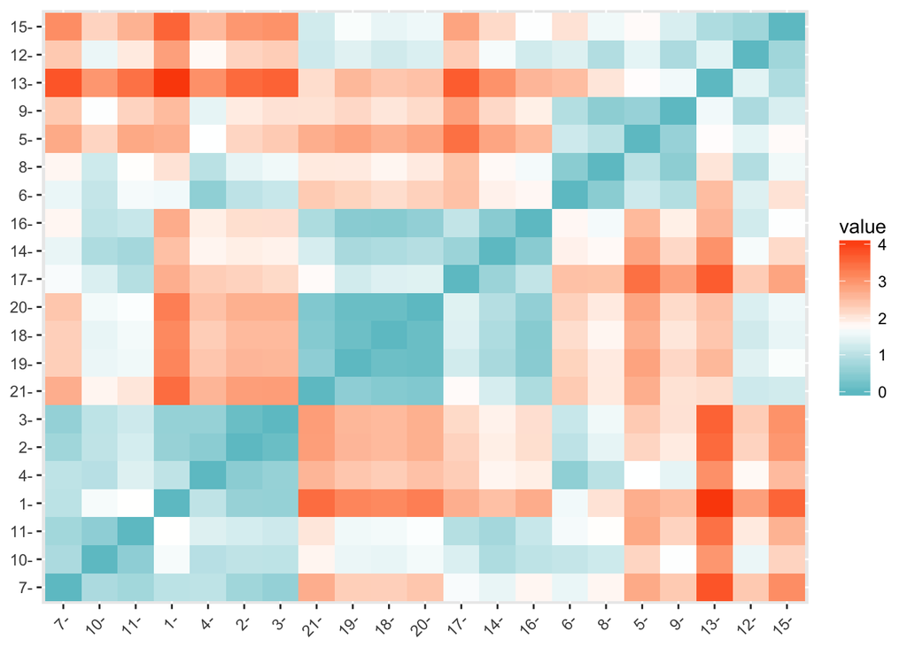

```r
res.dist <- get_dist(obser_final, stand = TRUE, method = "euclidean")
fviz_dist(res.dist,gradient = list(low = "#00AFBB", mid = "white", high = "#FC4E07"))
```

# Partitioning clustering

Partitioning algorithms are clustering techniques that subdivide the data sets into a set of k groups, where k is the number of groups pre-specified by the analyst.

There are different types of partitioning clustering methods. The most popular is the K-means clustering (MacQueen 1967), in which, each cluster is represented by the center or means of the data points belonging to the cluster. The K-means method is sensitive to outliers.

An alternative to k-means clustering is the K-medoids clustering or PAM (Partitioning Around Medoids, Kaufman & Rousseeuw, 1990), which is less sensitive to outliers compared to k-means.

Compute and visualize k-means clustering

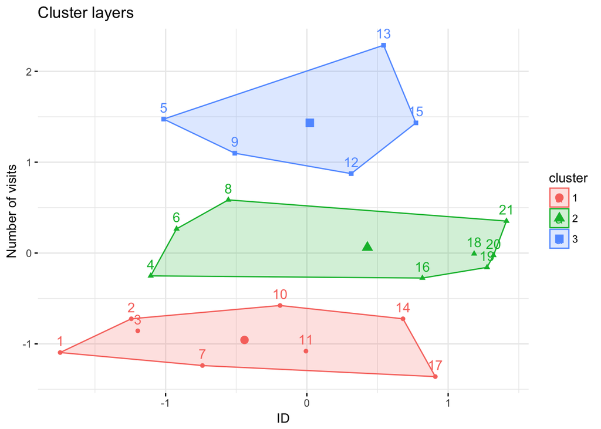

```r
set.seed(123)
km.res <- kmeans(obser_final, 3, nstart = 25)
# Visualize
fviz_cluster(km.res, data = obser_final,
            ellipse.type = "convex",
            palette = "rgb",
            ggtheme = theme_minimal(),xlab="ID",ylab="Number of visits",main="Cluster layers")
```

# Compute PAM

Similarly, the k-medoids/pam clustering can be computed as follow:

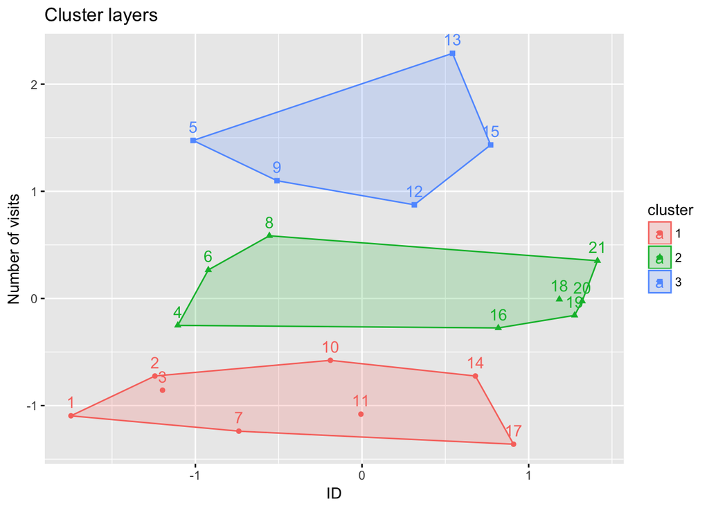

```r
pam.res <- pam(obser_final, 3)
#Visualize
fviz_cluster(pam.res,xlab="ID",ylab="Number of visits",main="Cluster layers")
```

# Hierarchical clustering

Hierarchical clustering is an alternative approach to partitioning clustering for identifying groups in the dataset. It does not require to pre-specify the number of clusters to be generated.

The result of hierarchical clustering is a tree-based representation of the objects, which is also known as dendrogram. Observations can be subdivided into groups by cutting the dendrogram at a desired similarity level.

Compute hierarchical clustering

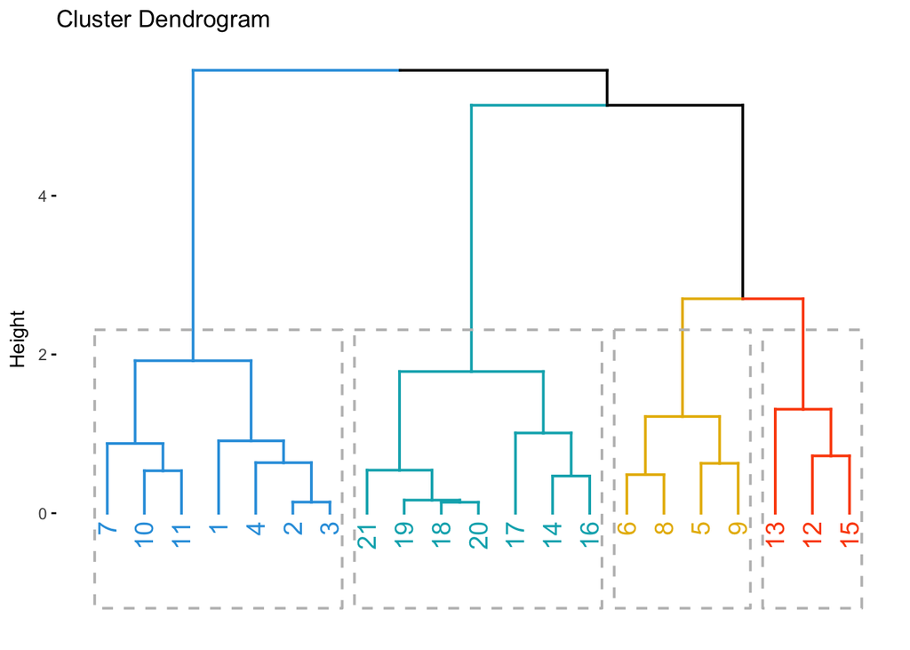

```r
res.hc <- obser_final %>%
 scale() %>%                    # Scale the data
 dist(method = "euclidean") %>% # Compute dissimilarity matrix
 hclust(method = "ward.D2")     # Compute hierachical clustering
# Visualize using factoextra
# Cut in 4 groups and color by groups
fviz_dend(res.hc, k = 4, # Cut in four groups
         cex = 1.0, # label size
         k_colors = c("#2E9FDF", "#00AFBB", "#E7B800", "#FC4E07"),
         color_labels_by_k = TRUE, # color labels by groups
         rect = TRUE # Add rectangle around groups
         )
```